# Data Project: Worksheet

# Premise

The goal of this document is to help you organize your thoughts and your work-flow for the group data project.

*You will not submit this document*

The goal of the project is to explore and wrangle an interesting data set, ultimately using it to answer two research questions. The work will be done in a small group of 3-4. The deliverable is fully developed report that introduces the data, describes any data management/wrangling, introduces two research questions, provides insightful visualizations, and performs statistical inference to provide answers

# Step 1: Examine the codebook, load the data.

The code book for the data is available as a handout in class and as a document in Canvas. Look it over. With your group, consider a few preliminary ideas about variables you might be particularly interested in, and what kinds of research questions might be appropriate. You can use this space to write a few notes if you desire.

### Requirements for your research questions:

- Inference should not be performed with a variable that has more than 5 levels (unless it’s day of the week or related to month). You are welcome to take a variable with more levels and transform it to have fewer, or take a quantitative variable and create two or more categories.
- At least one research question must consider the relationship between two variables.
- One research question may be a chi-square goodness of fit test for a single categorical variable (no tests for a test for a single mean or single proportion).
- To earn full credit, you must ask at least one research question that requires data manipulation (filter, mutate, etc)

Use the code-chunk below to load the data into the workspace and begin exploring your variables. Hint: look at data summaries, view a list of unique values for a variable, create some visualizations. This should help you decide if you want to continue pursuing your original ideas or whether you want to modify them.

```r
RawData <- read.csv(file.choose())
```

# Step 2: Write your research questions.

Write down what your research questions, and translate them into the correct hypothesis tests. Review the research question guidelines in step one if necessary

```r
glimpse(RawData)
```

```
Rows: 75,000
Columns: 28
$ incident_id                     <dbl> 20196001741, 20236010840, 20206013624, 2020356849, 20216014714, 2022532711, 20226020475, 20226017148, 2022259278, 2019604010, 2021305855, 20208044110, 20208025920, 2021291630,…
$ offense_type_id                 <chr> "criminal-mischief-graffiti", "theft-parts-from-vehicle", "theft-items-from-vehicle", "burglary-residence-by-force", "criminal-mischief-other", "criminal-mischief-mtr-veh", "t…
$ reported_date                   <chr> "2/27/2019 12:35:00 PM", "6/30/2023 9:11:00 PM", "10/9/2020 3:31:00 PM", "6/11/2020 12:30:00 AM", "7/13/2021 8:53:00 AM", "10/14/2022 6:25:00 PM", "11/2/2022 12:35:00 PM", "9/…
$ nbrhd_name                      <chr> "five-points", "dia", "jefferson-park", "indian-creek", "north-capitol-hill", "cherry-creek", "berkeley", "washington-park", "congress-park", "washington-park", "dia", "dia", …
$ victim_count                    <int> 1, 1, 1, 1, 1, 1, 1, 1, 1, 1, 1, 1, 1, 1, 1, 1, 1, 1, 1, 1, 1, 1, 2, 1, 1, 1, 1, 1, 1, 1, 1, 1, 1, 1, 1, 1, 1, 1, 1, 1, 1, 1, 1, 1, 1, 1, 1, 1, 1, 1, 1, 1, 1, 1, 1, 1, 1, 1, 1…
$ hour                            <int> 12, 21, 15, 0, 8, 18, 12, 10, 9, 1, 12, 17, 18, 22, 14, 5, 12, 13, 13, 19, 11, 11, 17, 20, 13, 13, 6, 10, 14, 16, 23, 11, 12, 13, 21, 14, 12, 20, 4, 11, 8, 8, 8, 8, 10, 18, 12…
$ day                             <chr> "Wednesday", "Friday", "Friday", "Thursday", "Tuesday", "Friday", "Wednesday", "Friday", "Friday", "Saturday", "Sunday", "Thursday", "Wednesday", "Sunday", "Thursday", "Thursd…
$ month                           <chr> "Feb", "Jun", "Oct", "Jun", "Jul", "Oct", "Nov", "Sep", "May", "Sep", "May", "Oct", "Jun", "May", "Dec", "May", "Sep", "Dec", "Jan", "Oct", "Dec", "Jan", "Feb", "May", "May", …
$ year                            <int> 2019, 2023, 2020, 2020, 2021, 2022, 2022, 2022, 2022, 2019, 2021, 2020, 2020, 2021, 2020, 2023, 2021, 2020, 2021, 2021, 2019, 2021, 2022, 2021, 2023, 2022, 2021, 2023, 2021, 2…
$ total_population                <int> 20221, 2314, 3795, 4000, 7295, 6428, 9130, 7302, 11445, 7302, 2314, 2314, 2314, 8859, 4631, 16718, 8907, 10386, 9130, 2314, 5921, 16120, 8225, 4439, 29939, 29939, 14885, 6050,…
$ percent_black                   <dbl> 11.71, 41.10, 2.56, 9.38, 7.02, 1.99, 0.84, 0.86, 4.61, 0.86, 41.10, 41.10, 41.10, 2.75, 6.91, 7.99, 2.54, 5.48, 0.84, 41.10, 9.54, 3.21, 5.43, 10.59, 9.00, 9.00, 8.04, 3.34, …
$ percent_white                   <dbl> 62.12, 26.10, 63.24, 63.80, 70.93, 83.95, 74.65, 89.14, 77.23, 89.14, 26.10, 26.10, 26.10, 26.48, 70.29, 70.89, 65.98, 55.40, 74.65, 26.10, 72.45, 73.94, 17.98, 32.24, 66.88, …
$ percent_native_american         <dbl> 0.46, 0.00, 0.00, 0.38, 0.22, 0.09, 0.11, 0.33, 0.29, 0.33, 0.00, 0.00, 0.00, 0.69, 0.00, 0.34, 0.08, 0.22, 0.11, 0.00, 0.59, 0.00, 0.55, 0.29, 0.55, 0.55, 0.50, 0.26, 0.00, 0…
$ percent_aapi                    <dbl> 1.78, 8.99, 2.71, 6.60, 2.96, 3.30, 2.11, 1.22, 3.59, 1.22, 8.99, 8.99, 8.99, 0.49, 2.79, 1.91, 4.06, 1.00, 2.11, 8.99, 2.08, 4.25, 8.43, 2.82, 7.97, 7.97, 3.02, 3.80, 2.74, 3…
$ percent_male                    <dbl> 54.44, 45.03, 55.52, 47.02, 48.10, 46.30, 48.23, 51.70, 50.69, 51.70, 45.03, 45.03, 45.03, 55.40, 61.93, 49.76, 46.03, 51.72, 48.23, 45.03, 44.98, 55.50, 54.53, 53.17, 49.45, …
$ percent_under18                 <dbl> 10.82, 29.13, 7.80, 16.40, 2.25, 5.63, 17.54, 18.27, 15.05, 18.27, 29.13, 29.13, 29.13, 25.47, 0.43, 15.72, 22.05, 16.16, 17.54, 29.13, 21.75, 1.55, 31.28, 25.32, 31.93, 31.93…
$ percent_65plus                  <dbl> 6.01, 6.09, 6.51, 21.58, 9.95, 41.51, 18.30, 24.95, 12.34, 24.95, 6.09, 6.09, 6.09, 9.79, 8.62, 22.45, 25.31, 12.40, 18.30, 6.09, 17.56, 10.33, 12.18, 7.37, 8.11, 8.11, 14.72,…
$ percent_in_school               <dbl> 12.93, 33.58, 12.57, 20.40, 10.42, 7.50, 16.41, 20.78, 15.87, 20.78, 33.58, 33.58, 33.58, 26.01, 25.67, 16.19, 24.80, 18.70, 16.41, 33.58, 19.86, 10.02, 24.43, 26.22, 28.65, 2…
```

[output cut: 10 more lines]

```r
tally(~offense_type_id, data = RawData |> group_by(offense_type_id)|> filter(!(grepl("burg", offense_type_id)|
                                            grepl("burglary", offense_type_id)|
                                            grepl("theft", offense_type_id)|
                                            grepl("robbery", offense_type_id)) & n()>=10))
```

```
offense_type_id
        agg-aslt-police-weapon                 agg-aslt-shoot             aggravated-assault              animal-cruelty-to                 arson-business                    arson-other                 assault-simple
                            18                             38                            436                             11                             11                             16                            653
                   bomb-threat     criminal-mischief-graffiti      criminal-mischief-mtr-veh        criminal-mischief-other           criminal-trespassing           disturbing-the-peace           drug-fraud-to-obtain
                            15                            740                           7539                           2588                            515                            106                             16
   drug-methampetamine-possess            drug-pcs-other-drug        drug-poss-paraphernalia                      extortion             false-imprisonment                 forgery-checks                  forgery-other
                            17                             22                             10                             46                             49                            129                             17
            fraud-by-telephone       fraud-by-use-of-computer   fraud-criminal-impersonation       fraud-nsf-closed-account                     harassment                 homicide-other                illegal-dumping
                           220                            242                             42                             13                            160                             28                             18
     intimidation-of-a-witness            kidnap-adult-victim         menacing-felony-w-weap    police-disobey-lawful-order       police-false-information            police-interference        police-resisting-arrest
                            14                             20                            222                             14                             14                             12                             15
         property-crimes-other      public-order-crimes-other       sex-off-fail-to-register              threats-to-injure       violation-of-court-order violation-of-restraining-order  weapon-by-prev-offender-powpo
                            12                             19                             33                            324                             93                            234                             13
     weapon-fire-into-occ-bldg       weapon-fire-into-occ-veh              weapon-other-viol   weapon-unlawful-discharge-of
                            95                             15                             14                            245
```

```r
tally(~offense_type_id, data = RawData)
```

```
offense_type_id
 accessory-conspiracy-to-crime         agg-aslt-police-weapon                 agg-aslt-shoot             aggravated-assault              animal-cruelty-to                 arson-business                    arson-other
                             3                             18                             38                            436                             11                             11                             16
         arson-public-building                arson-residence                  arson-vehicle          assault-police-simple                 assault-simple                         bigamy                    bomb-threat
                             2                              5                              7                              9                            653                              1                             15
                       bribery  burg-auto-theft-busn-no-force   burg-auto-theft-busn-w-force  burg-auto-theft-resd-no-force   burg-auto-theft-resd-w-force     burglary-business-by-force     burglary-business-no-force
                             3                             38                            110                            204                             39                           2563                            716
        burglary-poss-of-tools    burglary-residence-by-force    burglary-residence-no-force                  burglary-safe       burglary-vending-machine         contraband-into-prison     criminal-mischief-graffiti
                            31                           1968                           2694                             37                             46                              6                            740
     criminal-mischief-mtr-veh        criminal-mischief-other           criminal-trespassing      disarming-a-peace-officer           disturbing-the-peace           drug-cocaine-possess              drug-cocaine-sell
                          7539                           2588                            515                              1                            106                              2                              5
        drug-forgery-to-obtain           drug-fraud-to-obtain      drug-hallucinogen-possess               drug-heroin-sell      drug-make-sell-other-drug     drug-marijuana-cultivation         drug-marijuana-possess
                             3                             16                              1                              1                              2                              1                              3
           drug-marijuana-sell    drug-methampetamine-possess       drug-methampetamine-sell       drug-methamphetamine-mfr    drug-opium-or-deriv-possess       drug-opium-or-deriv-sell            drug-pcs-other-drug
                             1                             17                              6                              1                              1                              4                             22
       drug-poss-paraphernalia                         escape   explosive-incendiary-dev-pos   explosive-incendiary-dev-use                      extortion             false-imprisonment                 forgery-checks
                            10                              1                              2                              1                             46                             49                            129
    forgery-counterfeit-of-obj                  forgery-other     forgery-poss-of-forged-ftd    forgery-poss-of-forged-inst    forgery-posses-forge-device             fraud-by-telephone       fraud-by-use-of-computer
                             6                             17                              2                              5                              1                            220                            242
  fraud-criminal-impersonation       fraud-nsf-closed-account                     harassment                homicide-family                 homicide-other                illegal-dumping        impersonation-of-police
                            42                             13                            160                              1                             28                             18                              4
     intimidation-of-a-witness            kidnap-adult-victim              liquor-possession                      littering                      loitering         menacing-felony-w-weap       obscene-material-possess
                            14                             20                              5                              1                              2                            222                              1
    obstructing-govt-operation               pawn-broker-viol    police-disobey-lawful-order       police-false-information            police-interference      police-making-a-false-rpt        police-resisting-arrest
                             4                              9                             14                             14                             12                              2                             15
         property-crimes-other                public-fighting      public-order-crimes-other             public-peace-other          reckless-endangerment                   robbery-bank               robbery-business
```

[output cut: 13 more lines]

### Research Question 1:

H0: p_nE - p_nD = 0

Ha: p_nE - p_nD > 0

p_nE is the normalized proportion of the p_E proportion, and p_nD is the normalized proportion of the p_D proportion.

### Research Question 2:

Does of the percent of males in a neighborhood affect the average assault crime per thousand person of the neighborhood? (where assault crime per person is the number of assault crimes divided by the number of people in the neighborhood)

H0: There is no correlation between the percent of males in a neighborhood and the average assault per thousand? person

Ha: There is correlation between the percent of males in a neighborhood and the average assault per thousand person

Once you have your research questions, it is strongly recommended that you talk with your professor (*in lab*) about whether they can be answered with your data and what kind of data manipulation might be needed. You should think carefully about what type of data wrangling you think should be done. Your professor can help confirm your thoughts, or suggest different approaches. It’s possible you have a data wrangling idea that isn’t directly covered by the content in lecture. Your professor may be able to assist.

# Step 3: Perform the data manipulations

Use this space to manipulate the data in whatever way you deem necessary. We suggest you select only the variables you need to perform your data analysis.

```r
q1DataA <- RawData |> select(incident_id, offense_type_id, day) |> #get rid of all variables other than those we care about
            mutate(isAssault = case_when(grepl("aslt", offense_type_id)|grepl("assault", offense_type_id) ~ "Yes", #create new variable that is yes if the crime for the incident is Assault
                                                        .default = "No")) |> #Otherwise no
            mutate(isWeekend = case_when(grepl("Saturday", day)|grepl("Sunday", day) ~ "Yes", #create a new variable that is yes for weekend days
                                                        .default = "No"))|> #Otherwise no
            na.omit() #clean out bad data
glimpse(q1DataA)
```

```
Rows: 75,000
Columns: 5
$ incident_id     <dbl> 20196001741, 20236010840, 20206013624, 2020356849, 20216014714, 2022532711, 20226020475, 20226017148, 2022259278, 2019604010, 2021305855, 20208044110, 20208025920, 2021291630, 2020705878, 202…
$ offense_type_id <chr> "criminal-mischief-graffiti", "theft-parts-from-vehicle", "theft-items-from-vehicle", "burglary-residence-by-force", "criminal-mischief-other", "criminal-mischief-mtr-veh", "theft-items-from-…
$ day             <chr> "Wednesday", "Friday", "Friday", "Thursday", "Tuesday", "Friday", "Wednesday", "Friday", "Friday", "Saturday", "Sunday", "Thursday", "Wednesday", "Sunday", "Thursday", "Thursday", "Friday", "…
$ isAssault       <chr> "No", "No", "No", "No", "No", "No", "No", "No", "Yes", "No", "No", "No", "No", "No", "No", "No", "No", "No", "No", "No", "No", "No", "No", "No", "No", "No", "No", "No", "No", "No", "No", "No"…
$ isWeekend       <chr> "No", "No", "No", "No", "No", "No", "No", "No", "No", "Yes", "Yes", "No", "No", "Yes", "No", "No", "No", "No", "Yes", "No", "No", "No", "Yes", "No", "No", "No", "Yes", "Yes", "No", "Yes", "Ye…
```

```r
tally(~isAssault, data = q1DataA)
```

```
isAssault
   No   Yes
73846  1154
```

```r
tally(~offense_type_id, data = q1DataA)
```

```
offense_type_id
 accessory-conspiracy-to-crime         agg-aslt-police-weapon                 agg-aslt-shoot             aggravated-assault              animal-cruelty-to                 arson-business                    arson-other
                             3                             18                             38                            436                             11                             11                             16
         arson-public-building                arson-residence                  arson-vehicle          assault-police-simple                 assault-simple                         bigamy                    bomb-threat
                             2                              5                              7                              9                            653                              1                             15
                       bribery  burg-auto-theft-busn-no-force   burg-auto-theft-busn-w-force  burg-auto-theft-resd-no-force   burg-auto-theft-resd-w-force     burglary-business-by-force     burglary-business-no-force
                             3                             38                            110                            204                             39                           2563                            716
        burglary-poss-of-tools    burglary-residence-by-force    burglary-residence-no-force                  burglary-safe       burglary-vending-machine         contraband-into-prison     criminal-mischief-graffiti
                            31                           1968                           2694                             37                             46                              6                            740
     criminal-mischief-mtr-veh        criminal-mischief-other           criminal-trespassing      disarming-a-peace-officer           disturbing-the-peace           drug-cocaine-possess              drug-cocaine-sell
                          7539                           2588                            515                              1                            106                              2                              5
        drug-forgery-to-obtain           drug-fraud-to-obtain      drug-hallucinogen-possess               drug-heroin-sell      drug-make-sell-other-drug     drug-marijuana-cultivation         drug-marijuana-possess
                             3                             16                              1                              1                              2                              1                              3
           drug-marijuana-sell    drug-methampetamine-possess       drug-methampetamine-sell       drug-methamphetamine-mfr    drug-opium-or-deriv-possess       drug-opium-or-deriv-sell            drug-pcs-other-drug
                             1                             17                              6                              1                              1                              4                             22
       drug-poss-paraphernalia                         escape   explosive-incendiary-dev-pos   explosive-incendiary-dev-use                      extortion             false-imprisonment                 forgery-checks
                            10                              1                              2                              1                             46                             49                            129
    forgery-counterfeit-of-obj                  forgery-other     forgery-poss-of-forged-ftd    forgery-poss-of-forged-inst    forgery-posses-forge-device             fraud-by-telephone       fraud-by-use-of-computer
                             6                             17                              2                              5                              1                            220                            242
  fraud-criminal-impersonation       fraud-nsf-closed-account                     harassment                homicide-family                 homicide-other                illegal-dumping        impersonation-of-police
                            42                             13                            160                              1                             28                             18                              4
     intimidation-of-a-witness            kidnap-adult-victim              liquor-possession                      littering                      loitering         menacing-felony-w-weap       obscene-material-possess
                            14                             20                              5                              1                              2                            222                              1
    obstructing-govt-operation               pawn-broker-viol    police-disobey-lawful-order       police-false-information            police-interference      police-making-a-false-rpt        police-resisting-arrest
                             4                              9                             14                             14                             12                              2                             15
         property-crimes-other                public-fighting      public-order-crimes-other             public-peace-other          reckless-endangerment                   robbery-bank               robbery-business
```

[output cut: 13 more lines]

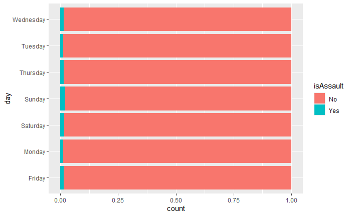

```r
gf_bar(day~isAssault, data = q1DataA, fill = ~isAssault, position = "fill")
```

```r
tally(isWeekend~isAssault, data = q1DataA)
```

```
         isAssault
isWeekend    No   Yes
      No  57538   832
      Yes 16308   322
```

```r
q1DataB <- RawData |> select(incident_id, offense_type_id, day) |> #get rid of all variables other than those we care about
            mutate(isDrug = case_when(grepl("drug", offense_type_id) ~ "Yes", #create new variable that is yes if the crime for the incident is a Burglary
                                                        .default = "No")) |> #Otherwise no
            mutate(isWeekend = case_when(grepl("Saturday", day)|grepl("Sunday", day) ~ "Yes", #create a new variable that is yes for weekend days
                                                        .default = "No"))|> #Otherwise no
            distinct(incident_id, offense_type_id, day, isDrug, isWeekend) |>
            na.omit() #clean out bad data
glimpse(q1DataB)
```

```
Rows: 75,000
Columns: 5
$ incident_id     <dbl> 20196001741, 20236010840, 20206013624, 2020356849, 20216014714, 2022532711, 20226020475, 20226017148, 2022259278, 2019604010, 2021305855, 20208044110, 20208025920, 2021291630, 2020705878, 202…
$ offense_type_id <chr> "criminal-mischief-graffiti", "theft-parts-from-vehicle", "theft-items-from-vehicle", "burglary-residence-by-force", "criminal-mischief-other", "criminal-mischief-mtr-veh", "theft-items-from-…
$ day             <chr> "Wednesday", "Friday", "Friday", "Thursday", "Tuesday", "Friday", "Wednesday", "Friday", "Friday", "Saturday", "Sunday", "Thursday", "Wednesday", "Sunday", "Thursday", "Thursday", "Friday", "…
$ isDrug          <chr> "No", "No", "No", "No", "No", "No", "No", "No", "No", "No", "No", "No", "No", "No", "No", "No", "No", "No", "No", "No", "No", "No", "No", "No", "No", "No", "No", "No", "No", "No", "No", "No",…
$ isWeekend       <chr> "No", "No", "No", "No", "No", "No", "No", "No", "No", "Yes", "Yes", "No", "No", "Yes", "No", "No", "No", "No", "Yes", "No", "No", "No", "Yes", "No", "No", "No", "Yes", "Yes", "No", "Yes", "Ye…
```

```r
tally(~isDrug, data = q1DataB)
```

```
isDrug
   No   Yes
74904    96
```

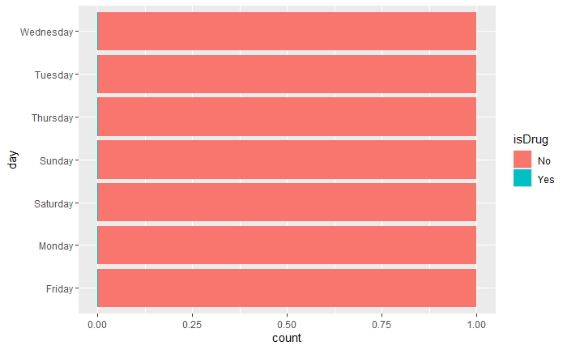

```r
#tally(~offense_type_id, data = q1DataB)
gf_bar(day~isDrug, data = q1DataB, fill = ~isDrug, position = "fill")
```

```r
tally(isWeekend~isDrug, data = q1DataB)
```

```
         isDrug
isWeekend    No   Yes
      No  58287    83
      Yes 16617    13
```

```r
q2Data <- RawData |> select(offense_type_id, nbrhd_name, percent_male, total_population) |> filter(grepl("aslt", offense_type_id)|grepl("assault", offense_type_id))
q2DataSummary <- q2Data |> mutate(nCrimes = sum())
```

[output not shown]

You should be able to clearly describe the data manipulations you perform, as well as the resulting variables.

# Step 4: Visualize your data

Produce two visualizations that help you gain insight into the research questions from part 2 (one for each). Think about what the visualizations tell you about your research question.

# Step 5: Perform inference (if appropriate)

Confirm that it is appropriate to use a distribution to perform inference, then perform the inference using prop.test, t.test, cor.test, or xchisq.test. You will need to do this twice, once for each research question.

# Step 6: Communicate your results

Based on the outcome of Step 5, you need to answer both your research questions.

# Step 7: Write the Report.

Take everything you’ve done in this worksheet and organize it using the DataProjectReportTemplate.

The text of your report must be less than *600 words*. To check the word count, go to Edit -> Word Count. The two figures will go at the end.

You’ll need to the follow sections (also described in the template):

### Introduction:

Introduce the dataset in your own words. Discuss, briefly, the motivation and curiousity behind your choice of research questions.

### Research question 1:

Write the research question in the section title and clearly detail any data manipulations you performed to be able to answer this research question. Do not include R code; use complete sentences to describe what you did.

- Write the relevant hypothesis test and clearly define the parameter of interest in the context of your research question.
- Discuss what kind of data visualization you created for this question, and what you learned from it as it relates to the research question. You will put this visualization at the end of the document.
- Introduce the inference procedure and report the p-value, as well as your conclusion in context. Make sure you discuss the strength of the evidence.

### Research question 1:

Write the research question in the section title and clearly detail any data manipulations you performed to be able to answer this research question. Do not include R code; use complete sentences to describe what you did.

- Write the relevant hypothesis test and clearly define the parameter of interest in the context of your research question.
- Discuss what kind of data visualization you created for this question, and what you learned from it as it relates to the research question. You will put this visualization at the end of the document.
- Introduce the inference procedure and report the p-value, as well as your conclusion in context. Make sure you discuss the strength of the evidence.

### Figures

One figure for each research questions in order.